# auto-ownership

suzanne

2024-03-20

## Load in Packages

IF YOU need to download some packages on github: travelSurveyTools, psrcelmer, and psrcplot. For this use the syntax: library(devtools) devtools::install_github(‘rsgInc/travelSurveyTools’) devtools::install_github(‘psrc/psrcelmer’) devtools::install_github(‘psrc/psrcplot’)

## Debugging travelSurveyTools

travelSurveyTools still has many cryptic error messages usually related to data or codebook formatting and naming. You may need to debug to find where or why the problem exists.

You can use: devtools::load_all(‘C:/GitHub/travelSurveyTools/R’) and then browser() and put breakpoints in the code to find the problem.

## Read in data items from Elmer

The travelSurveyTools package expects everything to be a data.table, so run setDT all over the place.

```r
household<- get_query(sql= "select household_id, survey_year, vehicle_count, hhincome_detailed, hh_weight
                from HHSurvey.v_households_labels")

setDT(household)
```

## Set IDs as characters

I guess for joining?, functionalize convert all ids to charcets

```r
household[, hh_id := as.character(household_id)]



household <- household%>%mutate(survey_year=as.character(survey_year))
```

## Make a new variable

If your variable is going to be a transformation of existing data in the codebook- for example grouping- you need to add the new variable and its new values to the internal to code, working codebook.

## Adding a new variable to the codebook

make a function with bunch of default #to do make this easier

```r
variable_list<-rbind(
    variable_list,
    data.table(
      variable = c("vehicle_count_simple"),
      is_checkbox = c(0),
      hh = c(1),
      person = c(0),
      day = c(0),
      trip = c(0),
      vehicle = c(0),
      location = c(0),
      description = c("vehicle_count_simple"),
      logic = c("vehicle_count_simple"),
      data_type = c("integer/categorical"),
      shared_name = c("vehicle_count_simple")
    )
  )
```

# Add associated values

```r
group_labels<-get_grouped_labels(group_id='group_1', group_name='vehicle_count_simple')
value_labels<-add_values_code(group_name='vehicle_count_simple')
household<-grp_to_tbl(tbl=household, ungrouped_name='vehicle_count', grouped_name='vehicle_count_simple')
```

The package expects the data to be in a list of data.tables.

```r
household <- household%>%filter(survey_year=='2023')

hts_data = list(hh = household)
```

```r
#some how a duplicate snuck into the variable list not sure how
variable_list<-variable_list%>%distinct(variable, .keep_all=TRUE)
```

##summarize data

```r
vehicle_summary = summarize_weighted(hts_data= hts_data,
                               summarize_var = 'vehicle_count_simple',
                               summarize_by = 'hhincome_detailed',
                               id_cols='household_id',
                               wt_cols='hh_weight',
                               wtname='hh_weight'
                               )
```

[output not shown]

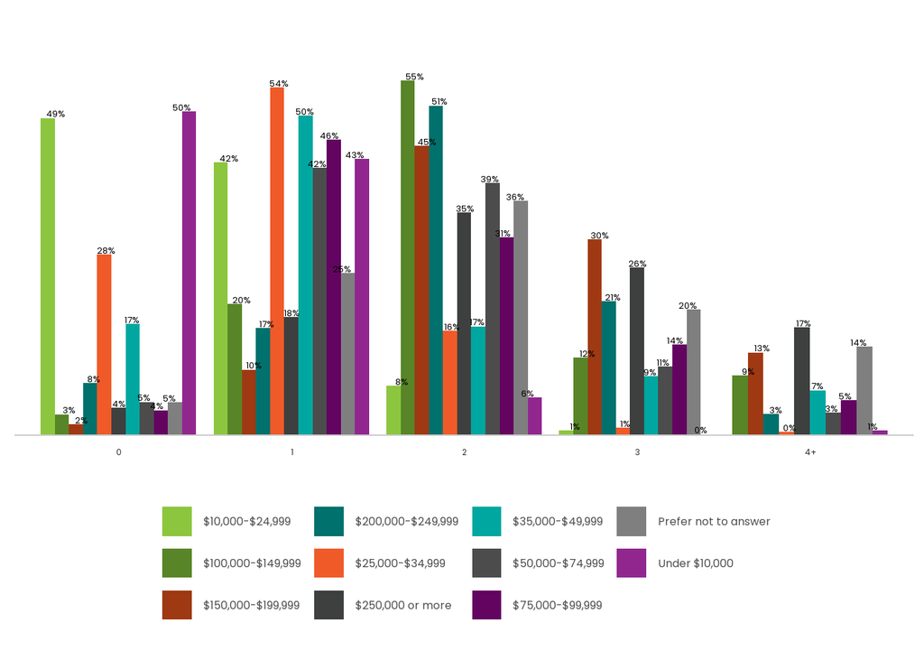

```r
vehs<-vehicle_summary$summary$wtd
vehs<-order_factors(vehs, 'hhincome_detailed', value_labels)

static_column_chart(vehs, x='vehicle_count_simple', y='prop', fill='hhincome_detailed', color='pgnobgy_10')
```

```r
vehs_pivot<-vehs%>%pivot_wider(id_cols=vehicle_count_simple, names_from=hhincome_detailed, values_from=prop )

write.csv(vehs_pivot, 'vehicles_by_hhincome.csv')
vehs_pivot
```

```
## # A tibble: 5 × 12
##   vehicle_count_simple `Under $10,000` `$10,000-$24,999` `$25,000-$34,999`
##   <chr>                          <dbl>             <dbl>             <dbl>
## 1 0                            0.503             0.493             0.281
## 2 1                            0.430             0.424             0.541
## 3 2                            0.0586            0.0762            0.162
## 4 3                            0.00129           0.00719           0.0115
## 5 4+                           0.00722          NA                 0.00472
## # ℹ 8 more variables: `$35,000-$49,999` <dbl>, `$50,000-$74,999` <dbl>,
## #   `$75,000-$99,999` <dbl>, `$100,000-$149,999` <dbl>,
## #   `$150,000-$199,999` <dbl>, `$200,000-$249,999` <dbl>,
## #   `$250,000 or more` <dbl>, `Prefer not to answer` <dbl>
```